# Chapter 05 part 1

Michael France Nelson

March, 2020

IMPORTANT NOTES

1. The data file for this exercise is in the **Course Data Files** folder at the top of the course Moodle page.
2. Because we are not using Excel for plotting or analysis you can skip the sections pertaining to Excel. Pay attention to the section titles if you don’t want to read more material than necessary.

# Correlograms: 5.3.3

NOTE: The first line of code in the book reads the data into a `data.frame` called `matrix`. DO NOT do this! `matrix` is the name of a function. R allows you to overwrite a function name in this way, but it is **extremely** bad practice.

## Import and plot vegetation matrix data

It might be nicer if the data were already in a raster format.

```r
file.exists(paste0(book_data, "cactus_matrix.csv"))
```

```
## [1] TRUE
```

```r
cactus_matrix = read.csv(paste0(book_data, "cactus_matrix.csv"))
str(cactus_matrix)
```

```
## 'data.frame':    676 obs. of  3 variables:
##  $ x     : int  0 0 0 0 0 0 0 0 0 0 ...
##  $ y     : int  0 2 4 6 8 10 12 14 16 18 ...
##  $ Height: int  35 65 75 60 80 20 65 40 60 85 ...
```

Here’s a way to make it a spatial points object:

```r
matrix_spdf = cactus_matrix
coordinates(matrix_spdf) = ~ x + y
```

Nice use of the `cut()` function:

```r
n_breaks = 17
cex_mat = 5
dev.off()
```

```r
par(mar = c(0, 0, 0, 0))
plot(
  cactus_matrix$x, cactus_matrix$y,
  pch = 22, col = 0, cex = cex_mat, asp = 1,
  bg = gray.colors(n_breaks)[cut(cactus_matrix[, 3], breaks = n_breaks)],
  ann = F, axes = F)
```

[output not shown]

Using the spatial points object:

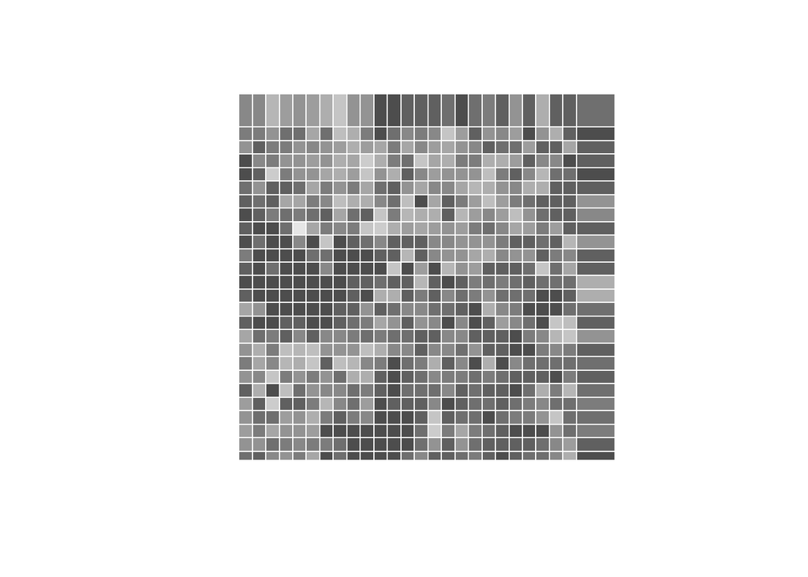

```r
plot(
  matrix_spdf,
  pch = 22, col = 0, cex = cex_mat, asp = 1,
  bg = gray.colors(n_breaks)[cut(cactus_matrix[, 3], breaks = n_breaks)],
  ann = F, axes = F)
```

## Build a distance matrix

We know that the measurements are points on a rectangular grid, spaced 2m apart.

The distances in the distance matrix will be cell-wise distances:

```r
matrix_dist = dist(cbind(cactus_matrix[, c("x", "y")]))
maxdist = (2 / 3) * max(matrix_dist)

matrix_dist_sp = spDists(matrix_spdf)
class(matrix_dist_sp)
```

```
## [1] "matrix"
```

## Correlogram using package `pgirmess`

```r
correlog_pgirmess = correlog(
  coordinates(matrix_spdf),
  matrix_spdf$Height,
  method = "Moran",
  nbclass = 14,
  alternative = "two.sided")

summary(correlog_pgirmess)
```

```
##    dist.class          coef              p.value                n
##  Min.   : 4.454   Min.   :-0.114735   Min.   :0.0000000   Min.   :  140
##  1st Qu.:20.405   1st Qu.:-0.027091   1st Qu.:0.0001074   1st Qu.:12248
##  Median :36.355   Median :-0.015721   Median :0.0811257   Median :35228
##  Mean   :36.355   Mean   :-0.006589   Mean   :0.2437166   Mean   :32593
##  3rd Qu.:52.306   3rd Qu.:-0.009189   3rd Qu.:0.5337699   3rd Qu.:53613
##  Max.   :68.257   Max.   : 0.191314   Max.   :0.7454132   Max.   :61012
```

```r
dev.off()
```

```r
plot(correlog_pgirmess)
abline(h = 0, lty = 2)
```

[output not shown]